# Practica_Viz

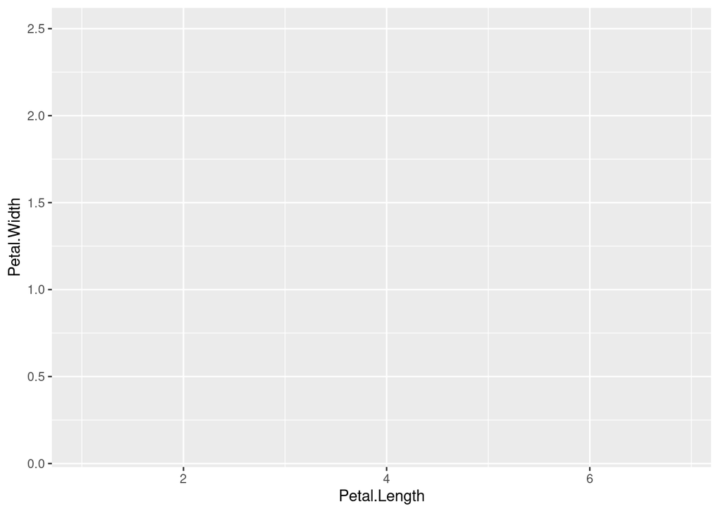

```r
p <-ggplot(iris, aes(
x=Petal.Length,
y=Petal.Width) )
p
```

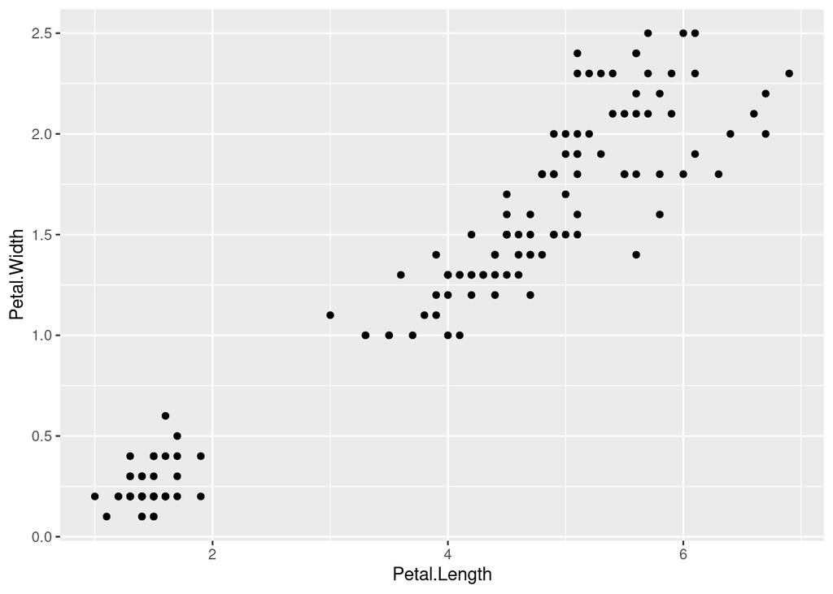

```r
p + geom_point()
```

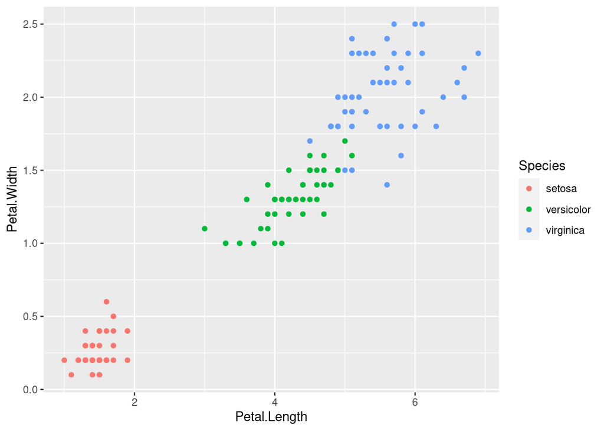

```r
ggplot(data=iris,
mapping=aes(x=Petal.Length,
y=Petal.Width,color=Species))+
geom_point()
```

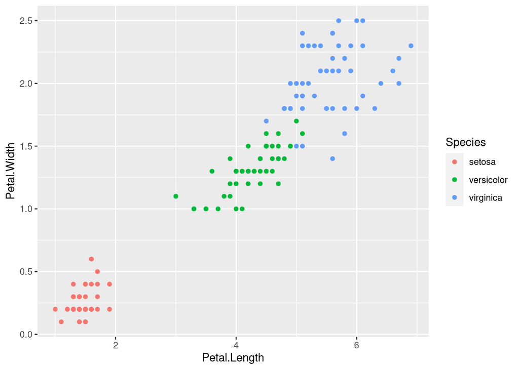

```r
ggplot(iris)+
geom_point(aes(x=Petal.Length,
y=Petal.Width,
color=Species))
```

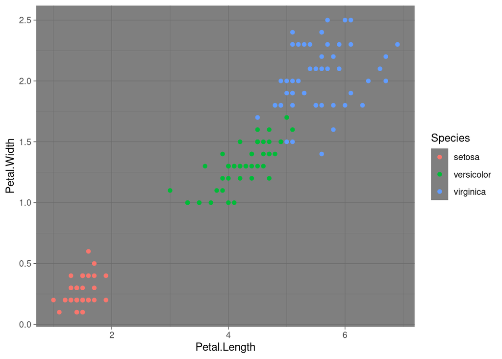

```r
p +
geom_point( aes(
x=Petal.Length,
y=Petal.Width,
color=Species) )+
theme_dark()
```

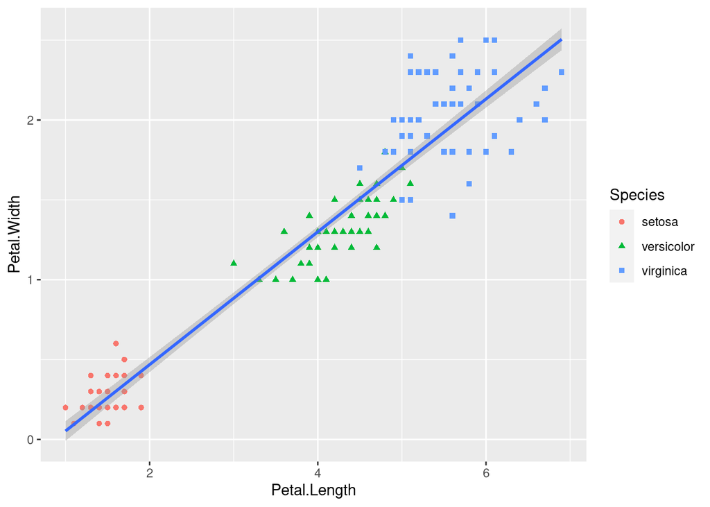

```r
ggplot(data = iris) +
 aes(x = Petal.Length,
y = Petal.Width) +
 geom_point(aes(color = Species,
shape = Species)) +
 geom_smooth(method = lm)
```

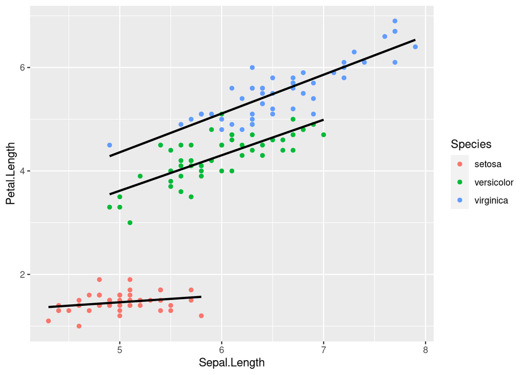

```r
# ggplot(iris) +
# aes(x=Sepal.Length, y=Petal.Length) +
#  geom_point(color = Species) +
# geom_smooth(aes(group = Species), method=lm, color='black', se=F)

ggplot(iris) +
  aes(x = Sepal.Length, y = Petal.Length, color = Species) +
  geom_point() +
  geom_smooth(aes(group = Species), method = lm, color = 'black', se = FALSE)
```

# Introducción

En este documento, exploraremos el conjunto de datos “iris”, que contiene información sobre diferentes especies de iris, y crearemos un gráfico de barras para visualizar la distribución de estas especies.

```r
#librerías
library(dendextend)
library(ggdendro)
library(ggplot2)
library(tidyverse)
library(factoextra)
library(cluster)
library(ggcorrplot)
library(viridis)
```

## Cargar el dataset

Primero, carguemos el conjunto de datos “iris” que viene incluido en R:

```r
# Cargar el conjunto de datos iris
iris <- datasets::iris

# Mostrar las primeras filas del conjunto de datos
head(iris)
```

|  | Sepal.Length | Sepal.Width | Petal.Length | Petal.Width | Species |
| --- | --- | --- | --- | --- | --- |
| 1 | 5.1 | 3.5 | 1.4 | 0.2 | setosa |
| 2 | 4.9 | 3.0 | 1.4 | 0.2 | setosa |
| 3 | 4.7 | 3.2 | 1.3 | 0.2 | setosa |
| 4 | 4.6 | 3.1 | 1.5 | 0.2 | setosa |
| 5 | 5.0 | 3.6 | 1.4 | 0.2 | setosa |
| 6 | 5.4 | 3.9 | 1.7 | 0.4 | setosa |

# Cargar la librería ggplot2

library(ggplot2)

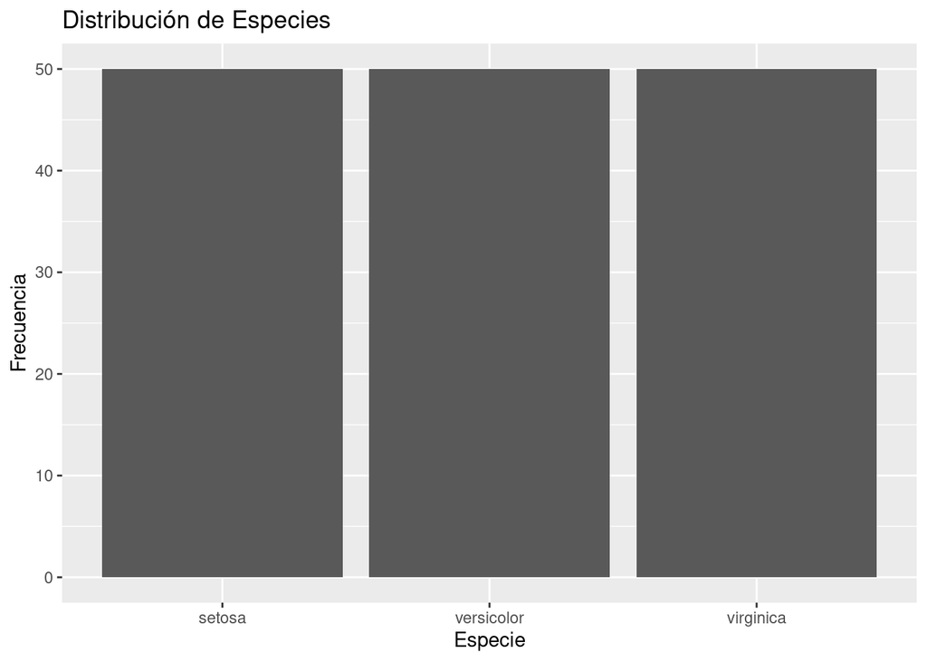

```r
# Crear un gráfico de barras de la distribución de especies
ggplot(iris, aes(x = Species)) +
  geom_bar(stat = "count") +
  labs(title = "Distribución de Especies", x = "Especie", y = "Frecuencia")
```

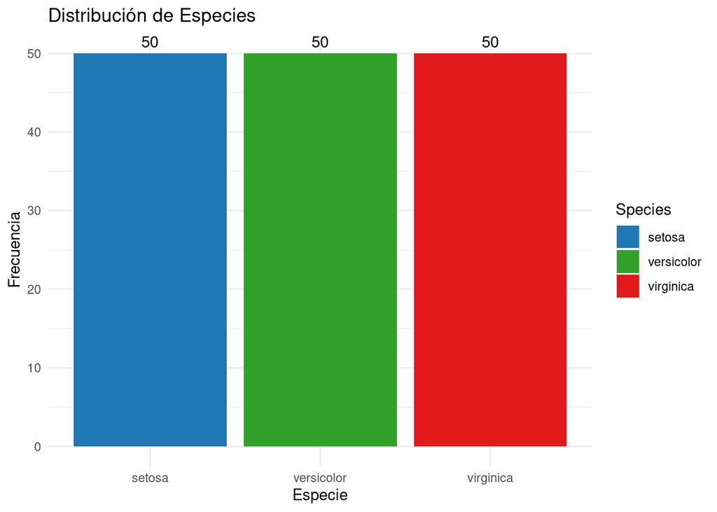

```r
mis_colores <- c("setosa" = "#1f78b4", "versicolor" = "#33a02c", "virginica" = "#e31a1c")

# Crea el gráfico de barras con ggplot
ggplot(iris, aes(x = Species, fill = Species)) +
  geom_bar() +
  # Personaliza los colores de las barras según la especie
  scale_fill_manual(values = mis_colores) +
  # Añade etiquetas a las barras
  geom_text(stat = "count", aes(label = ..count..), vjust = -0.5) +
  labs(title = "Distribución de Especies", x = "Especie", y = "Frecuencia") +
  theme_minimal()
```

El vector “mis_colores” asigna un color específico a cada especie. fill = Species en aes() asigna el color basado en la especie. scale_fill_manual() te permite especificar manualmente los colores. geom_text() añade etiquetas de frecuencia en la parte superior de cada barra. theme_minimal() ajusta el tema del gráfico para que se vea más limpio.

#Gráfico de dispersión

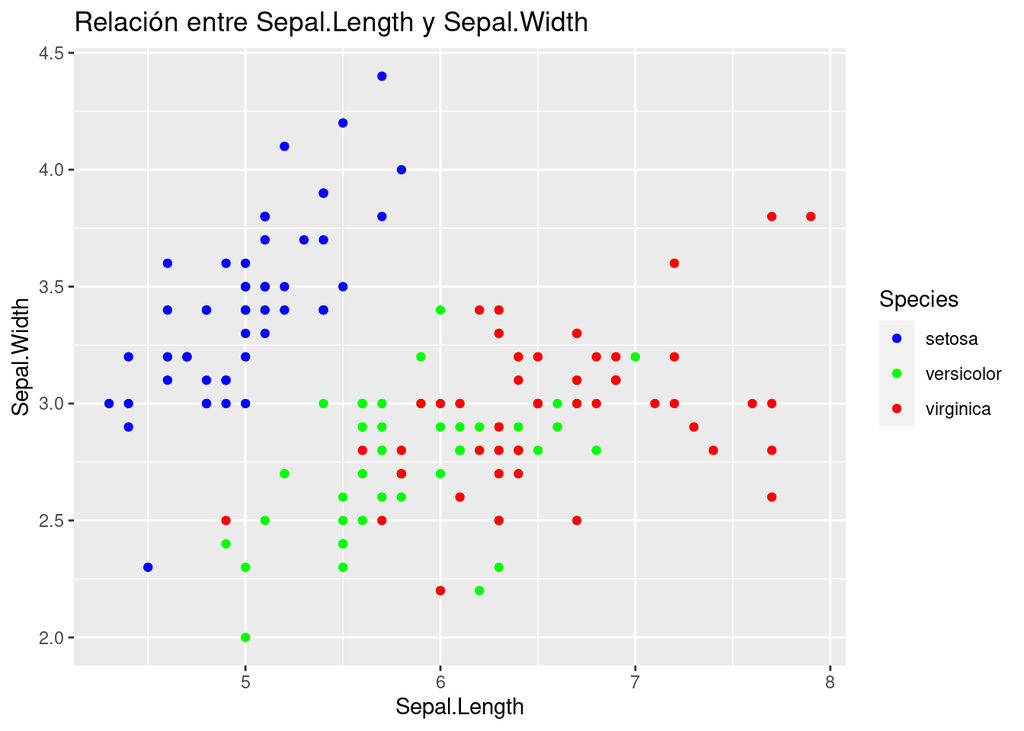

```r
#Probar otros colores
d<-ggplot(iris, aes(x = Sepal.Length, y = Sepal.Width, color = Species)) +
  geom_point() +
  labs(title = "Relación entre Sepal.Length y Sepal.Width",
       x = "Sepal.Length", y = "Sepal.Width")

#otra forma de usar colores
mis_colores2 <- c("setosa" = "blue", "versicolor" = "green", "virginica" = "red")

d + scale_color_manual(values = mis_colores2)
```

```r
# Cargar paleta de colores Viridis
library(viridis)

# Obtener una paleta de colores Viridis
mis_colores_viridis <- viridis_pal()(3)  # Obtener una paleta de 3 colores

# Cargar paleta de colores Magma
library(viridisLite)  # Paquete que contiene la paleta Magma

# Obtener una paleta de colores Magma
mis_colores_magma <- magma(3)  # Obtener una paleta de 3 colores

# Cargar paleta de colores Plasma
# No es necesario cargar ningún paquete adicional, ya que Plasma viene con el paquete 'viridisLite'

# Obtener una paleta de colores Plasma
mis_colores_plasma <- plasma(3)  # Obtener una paleta de 3 colores

# Obtener una paleta de colores Inferno
mis_colores_inferno <- inferno(3)  # Obtener una paleta de 3 colores
```

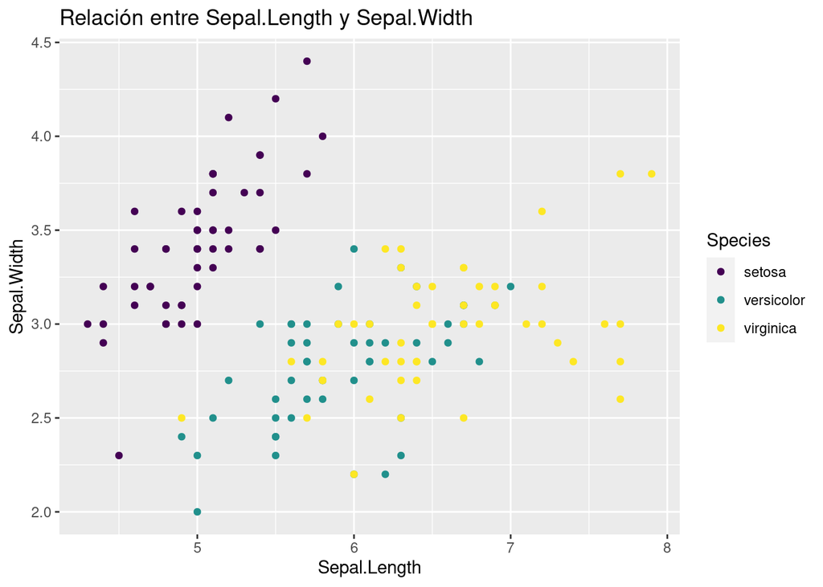

```r
#ejemplo
d + scale_color_manual(values = mis_colores_viridis)
```

#Correlación La correlación es una medida estadística que describe la relación entre dos variables. Indica cómo cambian juntas dos variables, es decir, si una variable aumenta, ¿la otra también tiende a aumentar (correlación positiva), disminuir (correlación negativa) o permanecer constante (correlación nula)?

Una correlación positiva se acerca a 1, mientras que una correlación negativa se acerca a -1. Una correlación nula o cercana a 0 indica una falta de relación lineal entre las variables.

Código Para crear un correlograma en R, primero calculamos la matriz de correlación utilizando la función cor(). Luego, visualizamos esta matriz utilizando la función ggcorrplot() del paquete ggcorrplot.

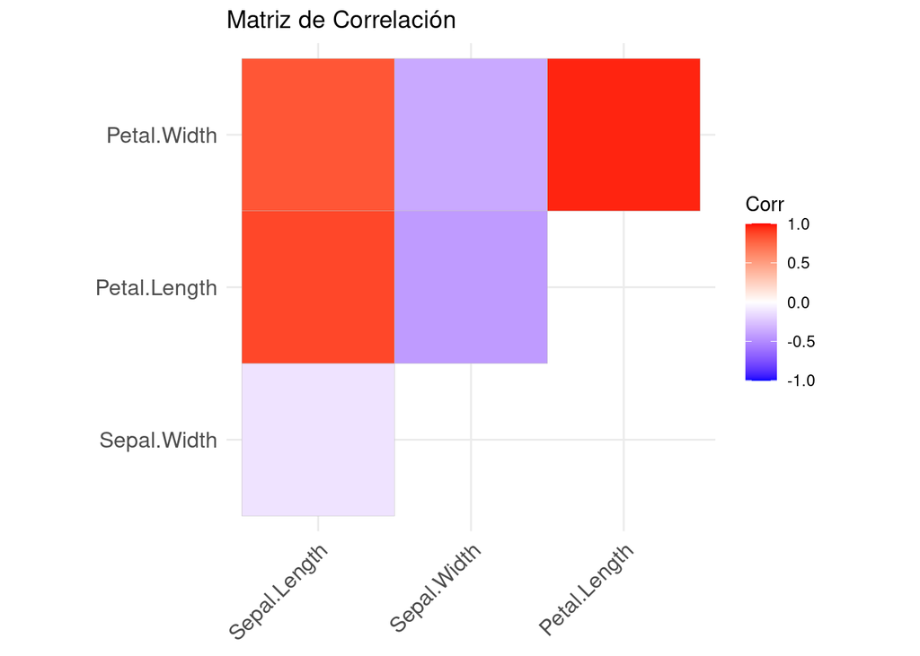

```r
# Calcular la matriz de correlación para las variables numéricas de iris
cor_matrix <- cor(iris[, -5])

# Visualizar la matriz de correlación con ggcorrplot
library(ggcorrplot)
ggcorrplot(cor_matrix, type = "upper") +
  labs(title = "Matriz de Correlación")
```

Código Para crear un heatmap en R, utilizamos la función heatmap(). Primero, calculamos la matriz de correlación utilizando la función cor(), y luego pasamos esta matriz como argumento a heatmap().

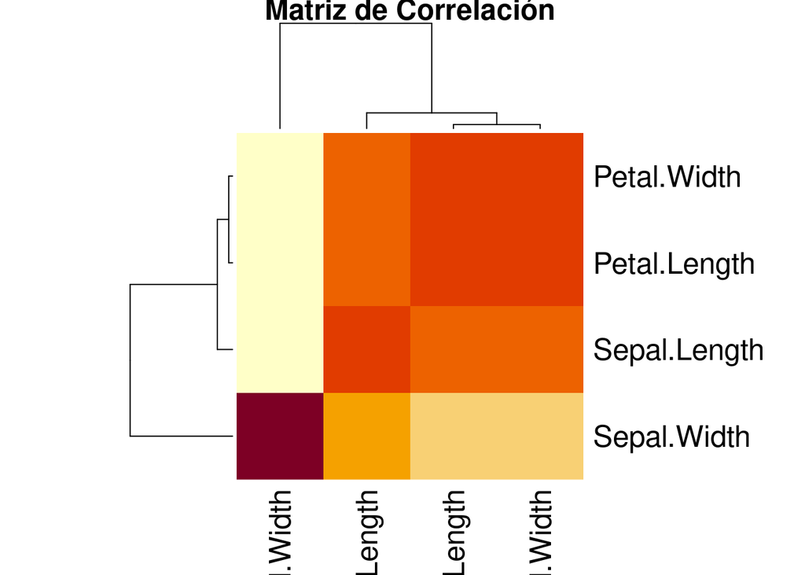

```r
#heatmap
heatmap(cor(iris[, -5]), main = "Matriz de Correlación")
```

Se ve cortado abajo. ¿Qué podemos hacer?

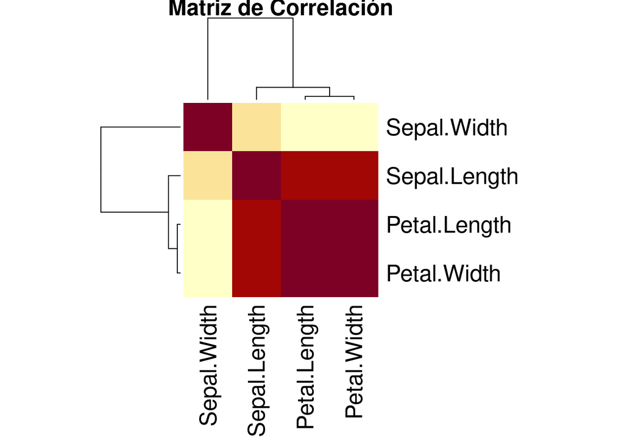

```r
heatmap(cor(iris[, -5]), main = "Matriz de Correlación", cex.axis = 0.6, cex.main = 1, symm = TRUE,
        las = 2, margins = c(10,10))
```

El parámetro margins en la función heatmap() controla los márgenes (espacios en blanco) alrededor del heatmap. Puedes especificar los márgenes tanto en la parte superior e inferior como en la izquierda y la derecha del heatmap.

La estructura de margins es c(margin_bottom_top, margin_left_right). Es decir, el primer valor en margins controla el espacio en blanco en la parte superior e inferior del heatmap, mientras que el segundo valor controla el espacio en blanco en la izquierda y derecha del heatmap.

Por ejemplo, si especificas margins = c(10, 10), estás diciendo que deseas 10 unidades de espacio en blanco tanto arriba y abajo como a la izquierda y derecha del heatmap. Esto puede ayudar a proporcionar más espacio para las etiquetas de los ejes y evitar que se corten.

cex.axis = 0.6: Este argumento controla el tamaño de la fuente de las etiquetas de los ejes x e y. Un valor de cex.axis menor que 1 reduce el tamaño de la fuente, mientras que un valor mayor que 1 aumenta el tamaño. Aquí, cex.axis = 0.6 reduce el tamaño de la fuente a un 60% del tamaño predeterminado.

cex.main = 1: Este argumento controla el tamaño de la fuente del título principal. Al igual que cex.axis, un valor menor que 1 reduce el tamaño y un valor mayor que 1 aumenta el tamaño. Aquí, cex.main = 1 establece el tamaño de la fuente del título principal al tamaño predeterminado.

symm = TRUE: Este argumento especifica si la matriz de entrada es simétrica o no. Aquí, symm = TRUE indica que la matriz de correlación es simétrica.

las = 2: Este argumento controla la orientación de las etiquetas de los ejes. las = 0 muestra las etiquetas de manera horizontal, las = 1 muestra las etiquetas inclinadas a 45 grados, las = 2 muestra las etiquetas de manera vertical. Aquí, las = 2 muestra las etiquetas de manera vertical.

Puedes ajustar estos valores según tus preferencias para lograr el diseño deseado en tu gráfico.

#Dendrograma, clustering jerárquico

Clustering jerárquico es un método de análisis de datos que agrupa objetos similares en grupos llamados “clústeres”. En el clustering jerárquico, los objetos se agrupan en una estructura jerárquica donde los clústeres se dividen y fusionan en cada nivel del árbol, formando así una estructura de árbol conocida como dendrograma.

El dendrograma es una representación gráfica de la estructura jerárquica resultante del clustering jerárquico. En un dendrograma, cada hoja representa un objeto individual, y las ramas y los nodos internos representan los clústeres que se forman al unir objetos similares. La altura en el dendrograma indica la distancia o similitud entre los objetos.

```r
#Cálculo matriz de distancia
iris_dist <- dist(iris[, -5])

#calfulo de clusters
iris_hc <- hclust(iris_dist)
```

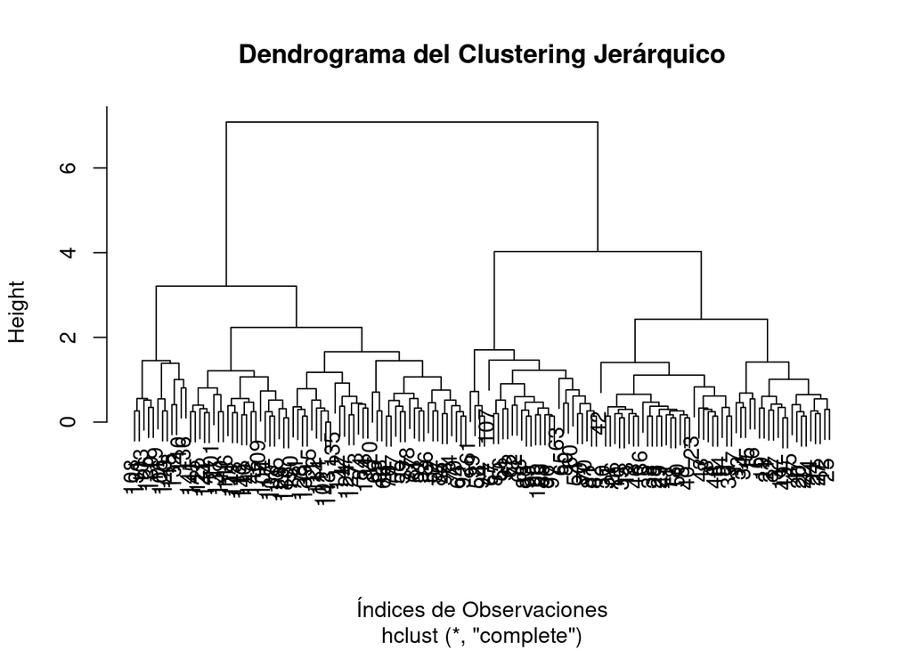

```r
plot(iris_hc, main = "Dendrograma del Clustering Jerárquico", xlab = "Índices de Observaciones", sub = NULL)
```

iris_dist <- dist(iris[, -5]): Se calcula una matriz de distancias entre las observaciones del conjunto de datos “iris”, excluyendo la columna de especies.

iris_hc <- hclust(iris_dist): Se aplica el algoritmo de clustering jerárquico a la matriz de distancias para construir un dendrograma.

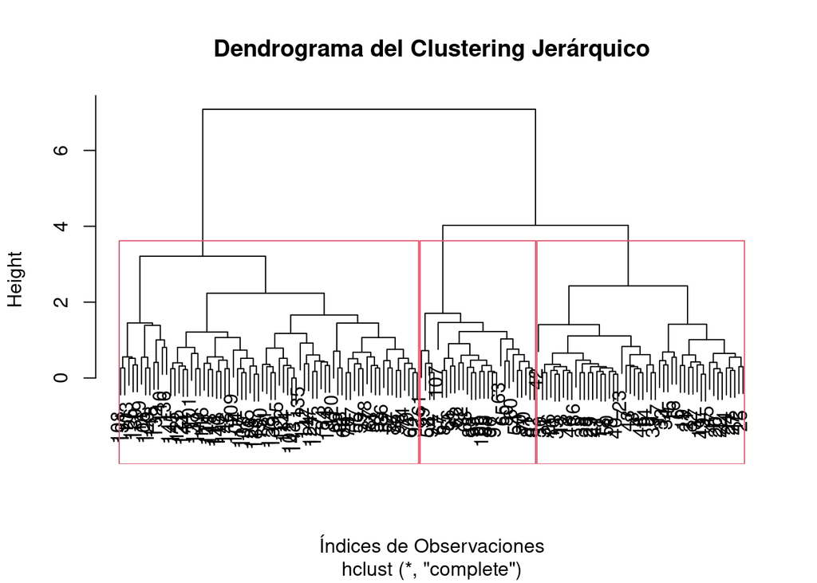

```r
plot(iris_hc, main = "Dendrograma del Clustering Jerárquico", xlab = "Índices de Observaciones", sub = NULL)

rect.hclust(iris_hc, k = 3) #k es igual al número de clusters
```

# Graficar con ggplot2

```r
library(dendextend)
library(ggdendro)
# Convertir el objeto hclust en un dendrogram
iris_dend <- as.dendrogram(iris_hc)

# Visualizar el dendrograma con ggplot2
dend_data <- dendro_data(iris_dend)
```

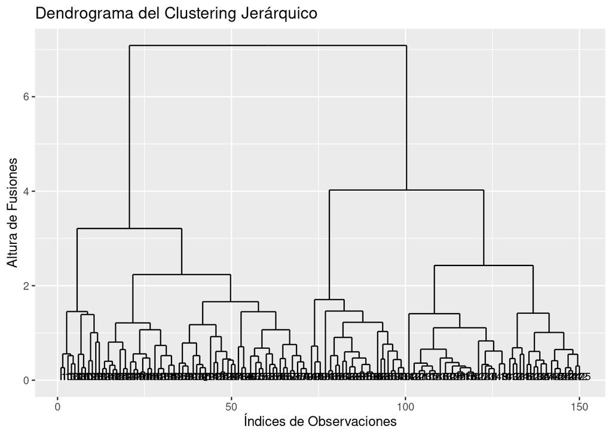

```r
# Plotear el dendrograma con ggplot2
ggplot() +
  geom_segment(data = dend_data$segments, aes(x = x, y = y, xend = xend, yend = yend)) +
  geom_text(data = dend_data$labels, aes(x = x, y = y, label = label), size = 3, hjust = 0, vjust = 0) +
  labs(title = "Dendrograma del Clustering Jerárquico", x = "Índices de Observaciones", y = "Altura de Fusiones")
```

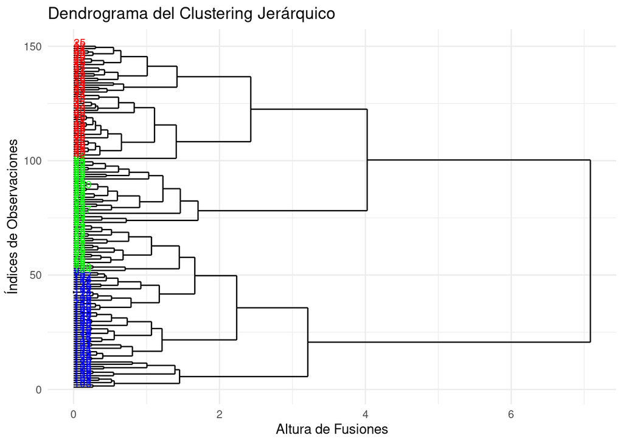

```r
dend_data$labels$Species <- factor(iris$Species)

ggplot() +
  geom_segment(data = dend_data$segments, aes(x = x, y = y, xend = xend, yend = yend)) +
  geom_text(data = dend_data$labels, aes(x = x, y = y, label = label, color = Species), size = 3, hjust = 0, vjust = 0) +
  scale_color_manual(values = c("setosa" = "blue", "versicolor" = "green", "virginica" = "red")) +  # Definir colores por especie
  labs(title = "Dendrograma del Clustering Jerárquico", x = "Índices de Observaciones", y = "Altura de Fusiones") +
  theme_minimal() +  # Opcional: agregar un tema
  theme(legend.position = "none") +  # Opcional: quitar la leyenda
  coord_flip()  # Opcional: rotar el dendrograma
```

##K-means Clustering El clustering K-means es un algoritmo de aprendizaje no supervisado que agrupa datos en K clústeres distintos basándose en las características de los datos. Funciona de la siguiente manera:

Inicializa K centroides aleatorios. Asigna cada punto de datos al centroide más cercano. Recalcula los centroides como la media de todos los puntos asignados a cada centroide. Repite los pasos 2 y 3 hasta que los centroides converjan o hasta que se alcance un número máximo de iteraciones. Este algoritmo busca minimizar la suma de las distancias cuadradas de cada punto de datos al centroide de su clúster.

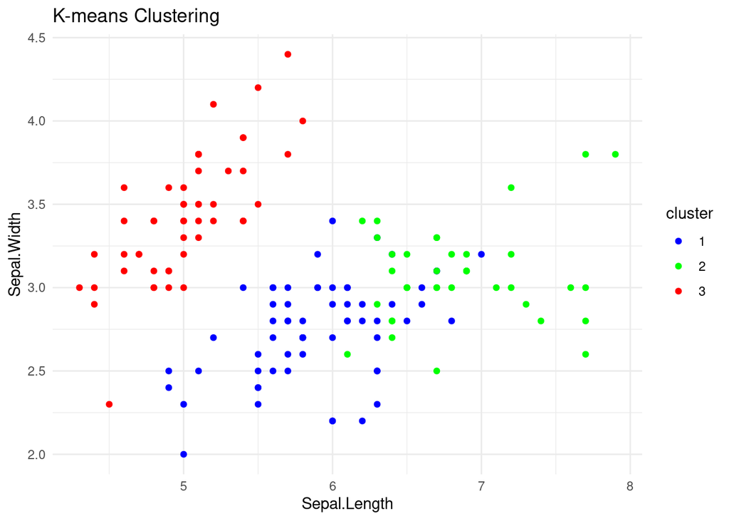

```r
kmeans_model <- kmeans(iris[, -5], 3)
iris$cluster <- factor(kmeans_model$cluster)
ggplot(iris, aes(x = Sepal.Length, y = Sepal.Width, color = cluster)) +
  geom_point() +
  scale_color_manual(values = c("1" = "blue", "2" = "green", "3" = "red")) +  # Definir colores por cluster
  labs(title = "K-means Clustering", x = "Sepal.Length", y = "Sepal.Width") +
  theme_minimal()  # Opcional: agregar un tema
```

Código

kmeans_model <- kmeans(iris[, -5], 3): Aplica el algoritmo K-means al conjunto de datos “iris” excluyendo la columna de especies (columna 5), dividiendo los datos en 3 clústeres. El resultado se guarda en kmeans_model. iris$cluster <- factor(kmeans_model$cluster): Asigna a cada observación en el conjunto de datos “iris” un clúster basado en el modelo K-means obtenido. Esta información se guarda en una nueva columna llamada “cluster”. ggplot(iris, aes(x = Sepal.Length, y = Sepal.Width, color = cluster)) + …: Utiliza ggplot2 para crear un gráfico de dispersión de “Sepal.Length” vs “Sepal.Width” con los puntos coloreados según el clúster al que pertenecen. scale_color_manual(values = c(“1” = “blue”, “2” = “green”, “3” = “red”)): Define manualmente la escala de colores para los clústeres, asignando colores específicos a cada clúster. labs(title = “K-means Clustering”, x = “Sepal.Length”, y = “Sepal.Width”): Establece los títulos para el gráfico y los ejes. theme_minimal(): Aplica un tema minimalista al gráfico para una apariencia más limpia y sencilla.

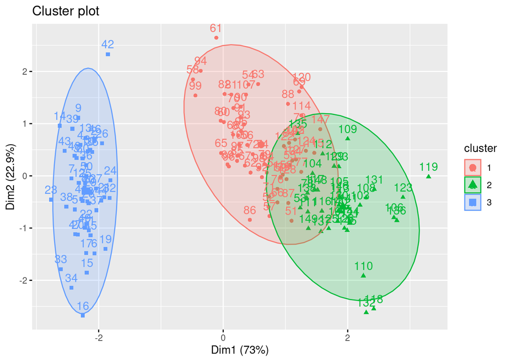

```r
fviz_cluster(kmeans_model, iris[, 1:4], ellipse.type = "norm")
```

ellipse.type = “norm”: Este argumento especifica el tipo de elipse que se va a dibujar alrededor de los clústeres en el gráfico. En este caso, “norm” indica que se deben dibujar elipses con la forma de la distribución normal alrededor de cada clúster.

##Biplot, PCA

Análisis de Componentes Principales (PCA) El Análisis de Componentes Principales (PCA) es una técnica de reducción de dimensionalidad que se utiliza para analizar y visualizar datos de alta dimensionalidad al proyectarlos en un nuevo espacio de coordenadas compuesto por las llamadas “componentes principales”. El objetivo principal del PCA es reducir la complejidad de los datos al mantener la mayor parte de su variabilidad en menos dimensiones.

El proceso básico del PCA implica calcular las componentes principales, que son combinaciones lineales de las variables originales que explican la mayor parte de la variabilidad en los datos. Las componentes principales están ordenadas de tal manera que la primera componente principal captura la mayor cantidad de variabilidad en los datos, la segunda componente principal captura la siguiente mayor cantidad de variabilidad, y así sucesivamente.

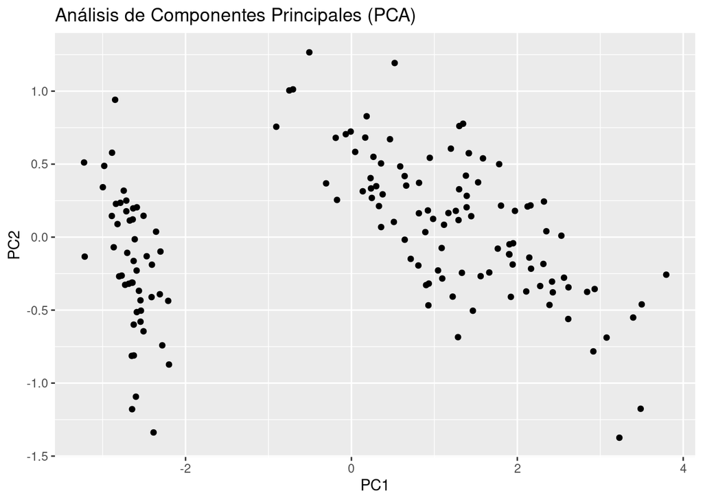

```r
# Realizar el PCA en el conjunto de datos 'iris'
pca_iris <- prcomp(iris[, 1:4])

# Extraer las primeras dos componentes principales
PC1 <- pca_iris$x[, 1]
PC2 <- pca_iris$x[, 2]

# Crear un gráfico de dispersión con las dos primeras componentes principales
ggplot() +
  geom_point(data = data.frame(PC1 = PC1, PC2 = PC2), aes(PC1, PC2)) +
  labs(title = "Análisis de Componentes Principales (PCA)", x = "PC1", y = "PC2")
```